# README

laneharrison

Mon-01-10-2018

## subjective ratings by framework

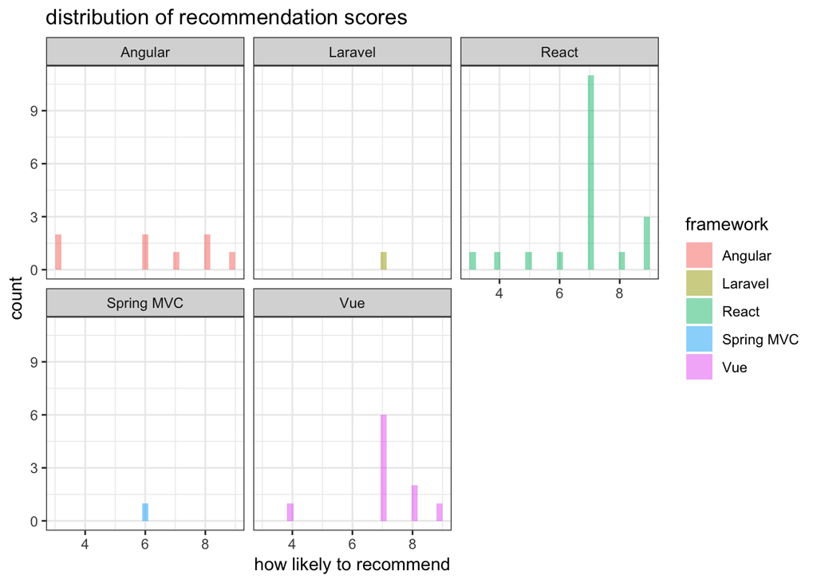

## perceived # of hours to learn

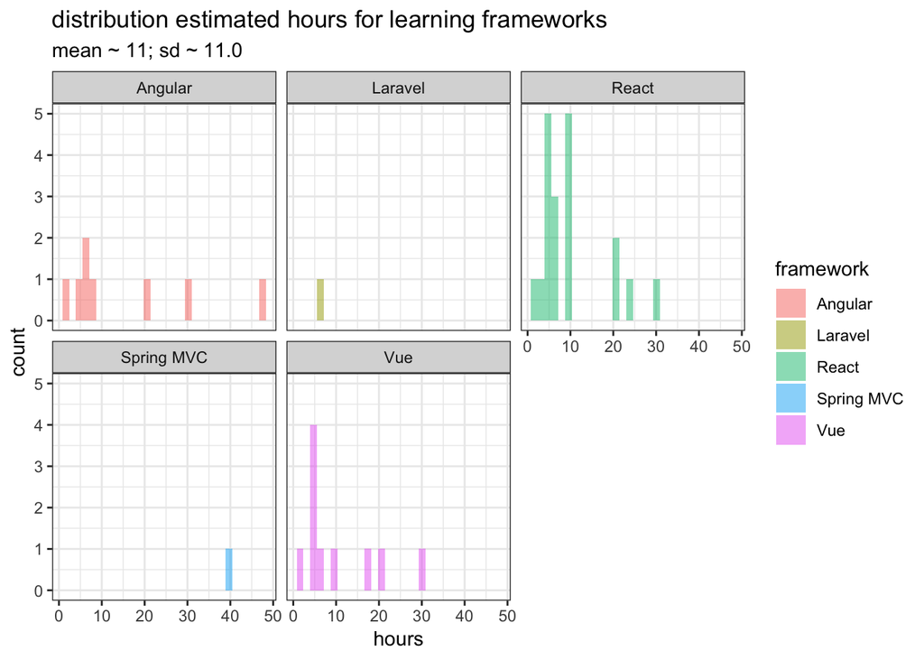

## scatterplot: recommendation scores vs. perceived number of hours to learn

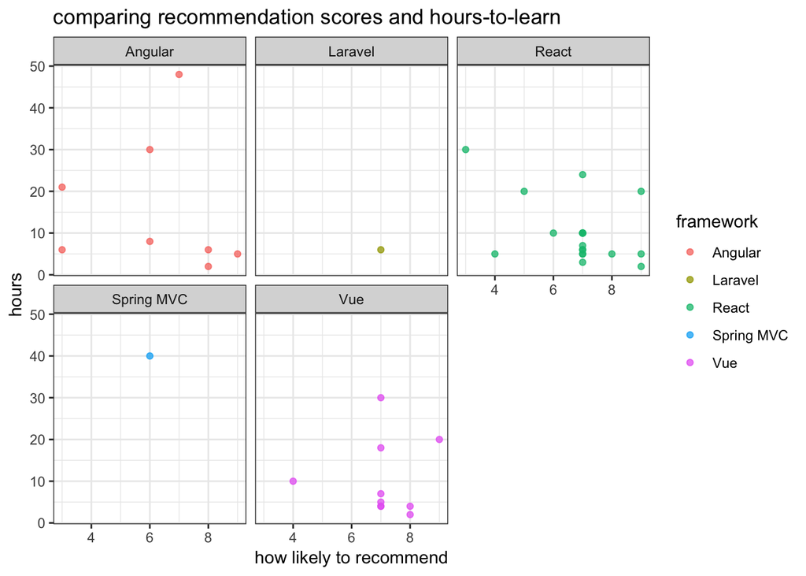

## table of resources by framework

Group Rows

Please specify the MVC framework you’re focusing on with this entry

How likely are you to recommend this framework to other students for their final project? Assume they have to learn it.

How many hours do you believe it would take someone who can create 3-tier webapps (e.g. a3) to learn this framework?

Please list in bullet points any key resources you would recommend folks use to learn this framework

**Angular**

Angular

6

8

NA

Angular

9

5

https://angular.io/tutorial

Angular

8

6

Angular Tutorial Website

Angular

3

21

NA

Angular

8

2

- https://angular.io/tutorial
- https://material.angular.io/components/categories <- Good for pre-built components that look great and are easy to work with
- USE THE ANGULAR CLI

Angular

7

48

NA

Angular

3

6

NA

Angular

6

30

https://angular.io

**Laravel**

Laravel

7

6

NA

**React**

React

7

10

NA

React

7

10

NA

React

7

6

NA

React

7

10

NA

React

7

24

https://tylermcginnis.com/reactjs-tutorial-a-comprehensive-guide-to-building-apps-with-react/

React

5

20

- udemy course (advanced web developer boot camp)

the react reference page

lots of time and patience

create-react-app is a simple way to start

React

7

5

- udemy zero to mastery course (for web dev in general)

React

8

5

- Wes Bos videos

reactjs.org

React

3

30

https://reactpatterns.com/

React

7

5

NA

React

7

7

udemy

React

7

10

It’s easy to learn but hard to scale (Hackathon’s choice) It’s hard to figure out how to get it to work with other libs

React

6

10

NA

React

9

2

ReactForBeginners

React

7

3

Udemy

React

4

5

NA

React

9

5

NA

React

9

20

the react’s tutorial

React

7

6

codeacademy

**Spring MVC**

Spring MVC

6

40

NA

**Vue**

Vue

7

5

NA

Vue

9

20

Simple syntax

Vue

8

2

Netninja

Vue

7

4

NA

Vue

8

4

NA

Vue

4

10

70

Vue

7

4

- React website

Stack overflow

Youtube videos

Vue

7

18

NA

Vue

7

7

*Youtube tutorials* vue.org tutorials

Vue

7

30

NA